# hw1_b11705048

### 統計學習與深度學習 (Fall, 2024)

### Homework 1

請將IPYNB檔與IPYNB Export之HTML檔上傳至COOL作業區。作業自己做。嚴禁抄襲。不接受紙本繳交，不接受遲交。請以英文或中文作答。 如無其他規定，所有重要結果應顯示至小數點第四位(四捨五入)。本次作業盡可能使用scikit-learn的函數與numpy進行實作。禁止使用Auto-SKlearn或其他AutoML工具。

#### 作者：資管三（B11705048）林杰

```python
import pandas as pd
import numpy as np
import random
from sklearn.preprocessing import OneHotEncoder
from sklearn import linear_model
from sklearn import metrics
import seaborn as sns
import matplotlib
import matplotlib.pyplot as plt

%matplotlib inline

pd.set_option('display.max_column', 500)
pd.set_option('display.max_rows', 5000)
random.seed(1001)
sns.set(font="Arial Unicode MS")
```

```python
#load the training data
dftrain = pd.read_csv('./housing_5cities_train.csv')
#load the test data
dftest = pd.read_csv('./housing_5cities_testa.csv')
print(f"Training df shape = {dftrain.shape}; test df shape = {dftest.shape}")
```

```
Training df shape = (8140, 21); test df shape = (1031, 21)
```

```python
dftrain.head()
```

|  | 縣市 | 鄉鎮市區 | 路名 | 土地面積 | 使用分區 | 移轉層次 | 總樓層數 | 主要用途 | 主要建材 | 建物型態 | 屋齡 | 建物面積 | 車位面積 | 車位個數 | 橫坐標 | 縱坐標 | 備註 | 主建物面積 | 陽台面積 | 附屬建物面積 | 單價 |
| --- | --- | --- | --- | --- | --- | --- | --- | --- | --- | --- | --- | --- | --- | --- | --- | --- | --- | --- | --- | --- | --- |
| 0 | 台北市 | 大安區 | 敦化南路二段 | -0.256716 | NaN | 11 | 11 | 住家用 | 鋼筋混凝土造 | 住宅大樓(11層含以上有電梯) | 32.583333 | -0.174154 | -0.819326 | 0.0 | 305266 | 2768378 | NaN | 0.393926 | 0.183700 | -0.438452 | 4.627714 |
| 1 | 高雄市 | 鳳山區 | 北忠街 | 0.181921 | NaN | 10 | 15 | 集合住宅 | 其他 | 住宅大樓(11層含以上有電梯) | 6.166667 | 0.423366 | 0.161624 | 1.0 | 184815 | 2504666 | NaN | -0.098871 | -0.360620 | 1.525881 | 1.489072 |
| 2 | 新北市 | 新莊區 | 福前街 | 0.085594 | NaN | 9 | 14 | 集合住宅 | 鋼筋混凝土造 | 住宅大樓(11層含以上有電梯) | 8.833333 | 0.164249 | 0.524653 | 1.0 | 296653 | 2772355 | NaN | -0.071147 | 0.315088 | 0.231984 | 2.051217 |
| 3 | 台北市 | 萬華區 | 國興路 | 0.260510 | NaN | 2 | 12 | 住家用 | 鋼筋混凝土造 | 住宅大樓(11層含以上有電梯) | 39.333333 | -0.411438 | -0.819326 | 0.0 | 301365 | 2768583 | NaN | -0.371295 | -0.618277 | -0.438452 | 2.238599 |
| 4 | 新北市 | 樹林區 | 信義街 | 0.856422 | NaN | 2 | 4 | 住家用 | 鋼筋混凝土造 | 公寓(5樓含以下無電梯) | 46.000000 | -0.868770 | -0.819326 | 0.0 | 292687 | 2763850 | NaN | -0.245408 | -1.642077 | -0.438452 | 1.348536 |

### 第一題 [Ridge Regression Baseline]

(30%) 以Ridge Regression進行房價預測。Regularizaiton coefficient (alphas)應考慮介於0.01至100之間的數值，且至少應考慮十種可能的數值。

訓練資料檔案為'housing_5cities_train.csv', 測試資料檔案為 'housing_5cities_testa.csv'。預測標的為'單價'。你的模型應包含以下特徵:

- 建物面積
- 總樓層數
- 屋齡
- 縣市
- 鄉鎮市區
- 主要用途
- 主要建材
- 建物型態

類別型特徵應進行適當的轉換。

(1) 畫出高雄市資料點的分布，橫坐標為x軸，縱坐標為y軸。依照單價將資料點上色。說明你對資料點個觀察。

(2) 列出最終選用的Regularization Coefficient，以下模型參數，並報告模型在測試資料的預測能力 (包含R2、RMSE、MAE、MAPE)。

- Constant term coefficient
- 建物面積
- 總樓層數
- 屋齡
- 台中市
- 台北市
- 新北市
- 桃園市
- 高雄市

#### Problem 1-(1)

畫出高雄市資料點的分布，橫坐標為x軸，縱坐標為y軸。依照單價將資料點上色。說明你對資料點個觀察。

Answer: 在以橫坐標為x軸，縱坐標為y軸的分布圖中，我將房價由低至高進行漸層上色。從下圖中可以看出，房屋單假較高的Cluster主要集中在橫坐標176000~180000、縱座標2500000~2510000這個範圍之間。這也是房屋較為密集的區域，可以推測此區域為市中心。不過市中心除了高房價的房子之外，也有不少被標為藍色的低房價建物。而在以上提到的區域外圍，房屋較為稀疏，也以標為藍色的低單價房屋為主。

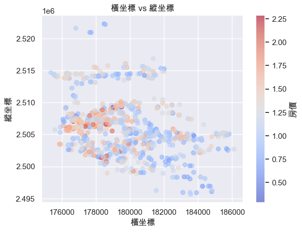

```python
dftrain_k = dftrain[dftrain['縣市'] == '高雄市']
plt.scatter(dftrain_k["橫坐標"].values, dftrain_k["縱坐標"].values, c=dftrain_k["單價"].values, cmap='coolwarm', alpha=0.6)
plt.xlabel('橫坐標')
plt.ylabel('縱坐標')
plt.title('橫坐標 vs 縱坐標')
plt.colorbar(label='房價')  # Add label to the colorbar
plt.show()
```

另外，我也將其他量化數據與單價的散佈圖畫出。以下為不同建物面積與樓層總數對於單價的散佈圖。可以發現高單價的房子多出現在高樓層的建物。

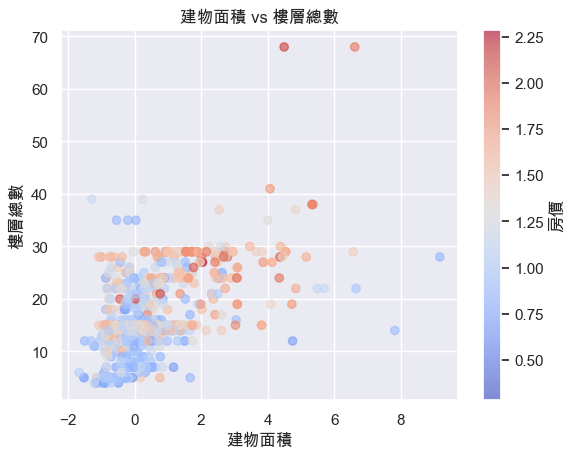

```python
#filter ‘縣市’ == '高雄市'
dftrain_k = dftrain[dftrain['縣市'] == '高雄市']

plt.scatter(dftrain_k["建物面積"].values, dftrain_k["總樓層數"].values, c=dftrain_k["單價"].values, cmap='coolwarm', alpha=0.6)
plt.xlabel('建物面積')
plt.ylabel('樓層總數')
plt.title('建物面積 vs 樓層總數')
plt.colorbar(label='房價')  # Add label to the colorbar
plt.show()
```

以下為不同樓層總數與屋齡對於單價的散佈圖。我們可以發現，高單價的房子多數屋齡較新且樓層總數較高。而樓層總數較低且屋齡較老的建物普遍單價較低。

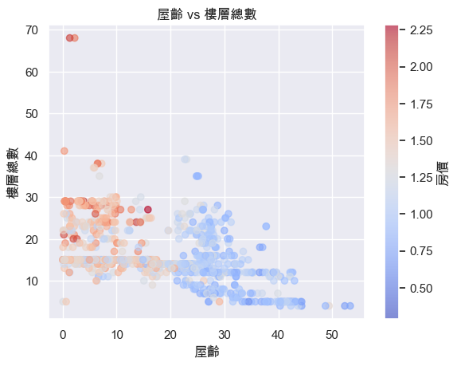

```python
plt.scatter(dftrain_k["屋齡"].values, dftrain_k["總樓層數"].values, c=dftrain_k["單價"].values, cmap='coolwarm', alpha=0.6)
plt.xlabel('屋齡')
plt.ylabel('樓層總數')
plt.title('屋齡 vs 樓層總數')
plt.colorbar(label='房價')  # Add label to the colorbar
plt.show()
```

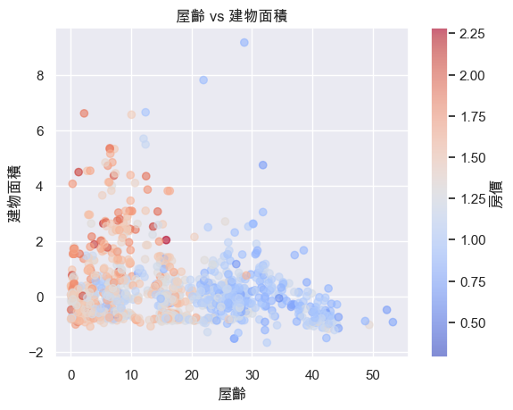

```python
plt.scatter(dftrain_k["屋齡"].values, dftrain_k["建物面積"].values, c=dftrain_k["單價"].values, cmap='coolwarm', alpha=0.6)
plt.xlabel('屋齡')
plt.ylabel('建物面積')
plt.title('屋齡 vs 建物面積')
plt.colorbar(label='房價')  # Add label to the colorbar
plt.show()
```

#### Problem 1-(2)

`gen_feature()` 函數將 categorical features 和 numerical features 都寫入 $\textbf{X}$ 這個 feature matrix。

- 分為 testing set 和 training set 處理。
- Categorical features 使用的是 one-hot encoding。

```python
def gen_features(dftrain, dftest, numfeatures, catfeatures, encoder):
    #training data
    X_train = dftrain[numfeatures]
    #learn how to encode the categorical features
    encoder.fit(dftrain[catfeatures])
    X_train_cat = encoder.transform(dftrain[catfeatures]).toarray()
    X_train = np.hstack((X_train, X_train_cat))

    #test data
    X_test = dftest[numfeatures]
    X_test_cat = encoder.transform(dftest[catfeatures]).toarray()
    X_test = np.hstack((X_test, X_test_cat))

    return X_train, X_test
```

以下 `fit_ridge_regression()` 函數實作 Ridge regression 的封閉解：$\mathbf{w} = \left( \lambda \mathbf{I} + \mathbf{\Phi}^\top \mathbf{\Phi} \right)^{-1} \mathbf{\Phi}^\top \mathbf{t}.$

```python
def fit_ridge_regression(X_train, y_train, lambda_val, reg_intercept = False):
    c0 = np.ones((X_train.shape[0], 1))
    X_train = np.hstack((c0, X_train))
    I = np.eye(X_train.shape[1])
    XTX = np.dot(X_train.T, X_train)
    if not reg_intercept:
        I[0, 0] = 0
    beta = np.linalg.inv(XTX + lambda_val * I) @ X_train.T @ y_train
    return beta
```

以下 `get_performance()` 函數將會回傳四個指標：

- **( $R^2$ )**: 決定係數，用來評估模型的擬合優度。

  $ R^2 = 1 - \frac{\sum_{i=1}^{n} (y_i - \hat{y}_i)^2}{\sum_{i=1}^{n} (y_i - \bar{y})^2} $

  其中，$ y_i $ 是真實值，$\hat{y}_i$ 是預測值，$\bar{y}$ 是真實值的平均值。
- **RMSE**: 均方根誤差（Root Mean Squared Error），用來衡量模型的預測誤差。

  $ RMSE = \sqrt{\frac{1}{n} \sum_{i=1}^{n} (y_i - \hat{y}_i)^2} $
- **MAE**: 平均絕對誤差（Mean Absolute Error），用來衡量預測值與真實值的差距。

  $ MAE = \frac{1}{n} \sum_{i=1}^{n} \left| y_i - \hat{y}_i \right| $
- **MAPE**: 平均絕對百分比誤差（Mean Absolute Percentage Error），用來衡量預測誤差佔真實值的比例。

  $ MAPE = \frac{100\%}{n} \sum_{i=1}^{n} \left| \frac{y_i - \hat{y}_i}{y_i} \right| $

```python
#beta is the coefficient
def get_performance(X, y, beta):
    # Compute R2, RMSE, MAE, MAPE given X, y, and beta
    # return R2, RMSE, MAE, MAPE as a list

    # y_mean = np.mean(y)
    # SST = np.sum((y - y_mean) ** 2)

    X = np.hstack((np.ones((X.shape[0], 1)), X))
    R_squared = metrics.r2_score(y, X @ beta)

    # compute SSE, RMSE, MAE, MAPE
    yhead = X @ beta
    error = yhead - y
    SSE = np.sum(error ** 2)
    MAE = np.mean(abs(error)) #L1 norm
    RMSE = (np.mean(error ** 2)) ** 0.5
    MAPE = np.mean(abs(error / y)) #element-wise division

    return R_squared, RMSE, MAE, MAPE
```

根據題目所指定，考慮以下特徵，並預測單價：

- Numerical features: 建物面積、總樓層數、屋齡
- Categorical features: 縣市、鄉鎮市區、主要用途、主要建材、建物型態

從下方的實驗得知，當 $\lambda$ 值為 2.0691 時，可以在 MAE 與 MAPE 兩個指標上獲得最好的結果，因此我在這裡使用的 $\lambda$ 值為 2.0691。我將資料跑了Ridge regression，題目所要求的參數如下：

- Const. :2.2050
- 建物面積 :0.0026
- 總樓層數 :0.0048
- 屋齡 :-0.0212
- 台中市 :-0.4505
- 台北市 :1.6265
- 新北市 :0.0566
- 桃園市 :-0.6216
- 高雄市 :-0.6109

模型的回歸係數顯示，建物面積（0.0026）和總樓層數（0.0048）對房價有正向影響，而屋齡（-0.0212）則呈負相關，表示隨著屋齡增長，房價會下降。此外，地區變數顯示台北市的房價相對基準城市高出 1.6265，而台中市、桃園市和高雄市的房價則相對較低，分別為 -0.4505、-0.6216 和 -0.6109。

```python
numfeatures = ['建物面積', '總樓層數', '屋齡']
catfeatures = ['縣市', '鄉鎮市區', '主要用途', '主要建材', '建物型態']
label = '單價'

y_train = dftrain[label].values
y_test = dftest[label].values

encoder = OneHotEncoder(handle_unknown='ignore')
X_train, X_test = gen_features(dftrain, dftest, numfeatures, catfeatures, encoder)
lambda_val = 2.0691
beta_head = fit_ridge_regression(X_train, y_train, lambda_val)


catnames = []
for a in encoder.categories_:
    catnames.extend(list(a))
#print(catnames)

for c, (abeta, aname) in enumerate(zip(beta_head, ['Const.'] + numfeatures + catnames)):
    if c > 8:
        print("... truncated ...")
        break
    print(f"{aname}\t{abeta:.4f}")
```

```
Const.	2.2050
建物面積	0.0026
總樓層數	0.0048
屋齡	-0.0212
台中市	-0.4505
台北市	1.6265
新北市	0.0566
桃園市	-0.6216
高雄市	-0.6109
... truncated ...
```

根據實驗，我最終選用的 Regularization Coefficient 為 2.0691。實驗細節會在下方詳加解釋。模型表現如下：

- $R^2$: 0.7680
- RMSE: 0.5044
- MAE: 0.2815
- MAPE: 0.1327

```python
r2, RMSE, MAE, MAPE = get_performance(X_test, y_test, beta_head)
print(f"R2 = {r2:.4f}; RMSE = {RMSE:.4f}; MAE = {MAE:.4f}; MAPE = {MAPE:.4f}")
```

```
R2 = 0.7680; RMSE = 0.5044; MAE = 0.2815; MAPE = 0.1327
```

以下為實驗各個 $\lambda$ 值的結果。我總共實驗了20個 $\lambda$ 值 （`np.geomspace(0.01, 100, num=20)`），並且針對題目所要求的個指標都畫出了 $\lambda$ 與指標的關係圖。

```python
def ridge_perf_by_alphas(X_train, y_train, lamgrids, perfname = "MAPE"):

    perf_train = np.zeros((len(lamgrids), 1))
    perf_test = np.zeros((len(lamgrids), 1))

    for ii, agrid in enumerate(lamgrids):
        beta_head2 = fit_ridge_regression(X_train, y_train, agrid)
        r2, RMSE, MAE, MAPE = get_performance(X_train, y_train, beta_head2)
        r2_test, RMSE_test, MAE_test, MAPE_test = get_performance(X_test, y_test, beta_head2)

        if perfname == "MAPE":
            perf_train[ii, 0] = MAPE
            perf_test[ii, 0] = MAPE_test
        elif perfname == "MAE":
            perf_train[ii, 0] = MAE
            perf_test[ii, 0] = MAE_test
        elif perfname == "RMSE":
            perf_train[ii, 0] = RMSE
            perf_test[ii, 0] = RMSE_test
        elif perfname == "R2":
            perf_train[ii, 0] = r2
            perf_test[ii, 0] = r2_test
        else:
            raise(Exception(f"Unknown perfname {perfname}"))

    return perf_train, perf_test
```

由實驗可以得知：

- Best MAPE= 0.1327 at $\lambda$ = 2.0691
- Best MAE= 0.2815 at $\lambda$ = 2.0691
- Best RMSE= 0.5043 at $\lambda$ = 0.4833
- Highest R2= 0.7681 at $\lambda$ = 0.4833

```
Best MAPE= 0.1327 at lambda = 2.0691
```

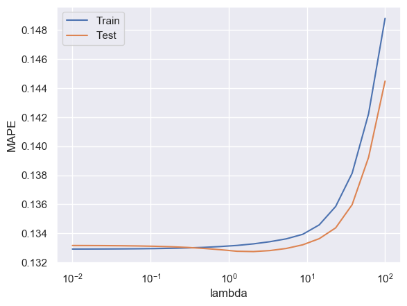

```
Best MAE= 0.2815 at lambda = 2.0691
```

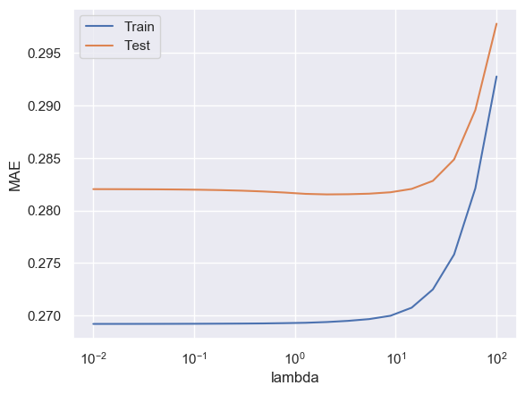

```
Best RMSE= 0.5043 at lambda = 0.4833
```

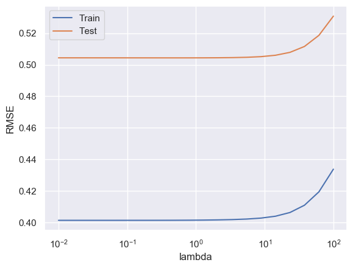

```
Best R2= 0.7681 at lambda = 0.4833
```

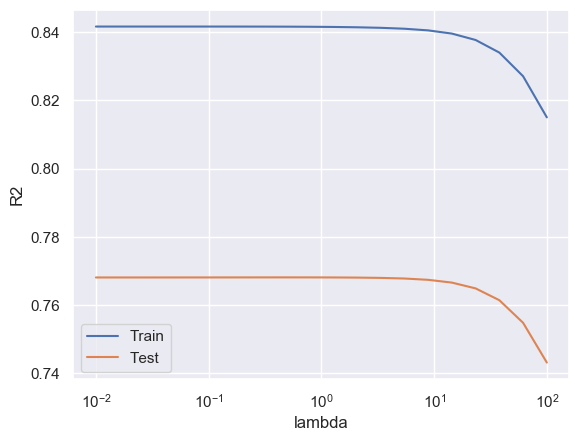

```python
#Cosider the range between 0.01 and 100
lamgrids = np.geomspace(0.01, 100, num=20)
performance_type = ["MAPE", "MAE", "RMSE", "R2"]

for i in performance_type:
    perf_train, perf_test = ridge_perf_by_alphas(X_train, y_train, lamgrids, perfname = i)

    if i == "R2":
        tmpind = np.argmax(perf_test)
    else:
        tmpind = np.argmin(perf_test)
    best_lambda = lamgrids[tmpind]
    best_mape_test = perf_test[tmpind, 0]
    print(f"Best {i}= {best_mape_test:.4f} at lambda = {best_lambda:.4f}")

    plt.plot(lamgrids, perf_train, label = "Train")
    plt.plot(lamgrids, perf_test, label = "Test")
    plt.xscale("log")
    plt.xlabel("lambda")
    plt.ylabel(i)
    plt.legend()
    plt.show()
```

### 第二題 [Gaussian Basis Function]

(30%) Gaussian Basis Function (GBF) 常用來擴展特徵。在房價預測中，我們可以挑選某些位置作為GBF的均數，並設定合理的變異數，即可利用GBF識別某筆資料是否為在選定的位置附近。

我們在課程中定義過一維情境下計算GBF特徵值的公式為:

$exp(- \frac{(x_a - \mu_j)^2}{2 s_j^2}), $

其中 $x_a$ 為資料點，而 $\mu_j$ 是選定的錨點 (Anchor)，標準差$s_j$ 是用來控管要訂多寬的區域。

房價資料的位置資訊為二維空間，因此如果資料點的位置是 $(x_a, y_a)$, 錨點是 $(\mu_{xj}, \mu_{yj})$、標準差是 $(s_{xj}, s_{yj})$，那GBF特徵值為:

$exp(- \frac{(x_a - \mu_{xj})^2}{2 s_{xj}^2} - \frac{(y_a - \mu_{yj})^2}{2 s_{yj}^2} )$

這題我們只選擇一個錨點，定為所有高雄市的訓練資料的中心點。X軸的標準差為高雄市的資料X座標的標準差，並利用相同的方式定Y軸的標準差。利用上面的公式計算GBF資料數值。

(1) 列出錨點座標與標準差

(2) 為所有訓練資料計算GBF特徵值，並且依照縣市列出這個特徵值的count, mean, std, min, 25%, 50%, 75%, max。

#### Problem 2-(1)

以下code將縣市為「高雄市」的資料篩選出來，並針對其計算錨點座標（$\mu_x, \mu_y$）。同時也依據題目要求，計算座標的標準差：

- 錨點座標: (179372.9859,2506459.4171)
- 橫坐標的標準差：2314.8228，縱座標的標準差：4033.3846。

同時，我也在這段code，根據上課簡報實作了`gaussian_basis_function()`。

```python
#anchor is (橫坐標平均, 縱坐標平均)，四捨五入到小數點第四位
anchor = (round(dftrain_k["橫坐標"].mean(), 4), round(dftrain_k["縱坐標"].mean(),4))
print(f"Anchor point: ({anchor[0]},{anchor[1]})")

std_x = dftrain_k["橫坐標"].std()
std_y = dftrain_k["縱坐標"].std()
print(f"Standard deviation of x: {std_x:.4f}; y: {std_y:.4f}.")

df_coor_k = dftrain_k[["橫坐標", "縱坐標"]].copy()

def gaussian_basis_function(df_coor_k, anchor, std_x, std_y):
    # Compute the Gaussian basis function given the dataframe df_coor_k, anchor point, and standard deviation
    # Return the basis function as a numpy array

    # Compute the Gaussian basis function
    x = df_coor_k["橫坐標"].values
    y = df_coor_k["縱坐標"].values
    phi = np.exp(-0.5 * (((x - anchor[0]) / std_x) ** 2 + ((y - anchor[1]) / std_y) ** 2))
    return phi
```

```
Anchor point: (179372.9859,2506459.4171)
Standard deviation of x: 2314.8228; y: 4033.3846.
```

#### Problem 2-(2)

以下的程式為所有訓練資料計算GBF特徵值，並且依照縣市列出這個特徵值的count, mean, std, min, 25%, 50%, 75%, max。

我們可以發現，高雄市的地理位置與其他四個縣市有較大的距離，因此在計算地理位置的 GBF 特徵值時，其他縣市的每一筆資料對於高雄市而言，特徵值均為 0。這種現象是因為 GBF 的計算方式而產生的特性，它反映了地理位置的距離特徵，因此當其他縣市的資料點與高雄市的距離較遠時，其特徵值接近於零。

```python
phi = gaussian_basis_function(dftrain, anchor, std_x, std_y)
#依照縣市列出這個特徵值的count, mean, std, min, 25%, 50%, 75%, max。
dftrain["Gaussian"] = phi
dftrain.groupby("縣市")["Gaussian"].describe()
```

| 縣市 | count | mean | std | min | 25% | 50% | 75% | max |
| --- | --- | --- | --- | --- | --- | --- | --- | --- |
| 台中市 | 810.0 | 0.000000 | 0.000000 | 0.000000 | 0.000000 | 0.000000 | 0.000000 | 0.000000 |
| 台北市 | 1906.0 | 0.000000 | 0.000000 | 0.000000 | 0.000000 | 0.000000 | 0.000000 | 0.000000 |
| 新北市 | 3432.0 | 0.000000 | 0.000000 | 0.000000 | 0.000000 | 0.000000 | 0.000000 | 0.000000 |
| 桃園市 | 925.0 | 0.000000 | 0.000000 | 0.000000 | 0.000000 | 0.000000 | 0.000000 | 0.000000 |
| 高雄市 | 1067.0 | 0.519141 | 0.292717 | 0.000432 | 0.258577 | 0.559224 | 0.763008 | 0.994381 |

### 第三題 [Applying GBF in Prediction Models]

(40%) 依照以下方式產生錨點，並使用GBF生成新的特徵，與第一題所有的特徵合併後，建構新的Ridge Regression預測模型，並計算其在測試資料上的預測能力(包含R2、RMSE、MAE、MAPE)。

對每個城市C，找出能包含所有資料點的長方形，並將橫軸與縱軸個切$K$等分，形成$K^2$個格子。如果一個格子內有超過20個資料點，計算這個格子內的所有資料點的均數與標準差，做為一個錨點。格子內如果少於20個資料點則直接略過這個格子。

(1) 列出各縣市的錨點。

(2) 設K=3, 列出測試資料的R2、RMSE、MAE、MAPE，並與第一題比較。

#### Problem 3-(1)

我依照題目設定將 $K$ 設為 3。首先，我先針對每個城市的九宮格計算$\mu_x, \mu_y, \sigma_x, \sigma_y$（排除資料點不到20的格子）。其中，每個格子內的 ($\mu_x, \mu_y$) 即為錨點。詳細的錨點資料於下方 Cell 的輸出列出。共有 32 個符合規定的方格。

```python
#get every unique value of the column '縣市'
cities = dftrain["縣市"].unique()

mu_x_all = []
mu_y_all = []
std_x_all = []
std_y_all =[]
count_all = []

ngrid = 3

for c in cities:
    df_train_city = dftrain[dftrain["縣市"] == c]
    print(f"City: {c}, shape = {df_train_city.shape}")
    coord_x = df_train_city["橫坐標"].values
    coord_y = df_train_city["縱坐標"].values
    xmin = coord_x.min()
    xmax = coord_x.max()+0.1
    ymin = coord_y.min()
    ymax = coord_y.max()+0.1

    x_grid = np.linspace(xmin, xmax, ngrid+1)
    y_grid = np.linspace(ymin, ymax, ngrid+1)

    for i in range(ngrid):
        for j in range(ngrid):
            #check if the coordinate is within each grid
            tmpindx = (x_grid[i] <= coord_x) * (coord_x < x_grid[i+1])
            tmpindy = (y_grid[j] <= coord_y) * (coord_y < y_grid[j+1])
            tmpind = tmpindx * tmpindy
            npoints = np.sum(tmpind)
            if npoints < 20:
                print(f"Only {npoints} points in grid {i}, {j} for city {c}.")
                continue
            mu_x = np.mean(coord_x[tmpind])
            mu_y = np.mean(coord_y[tmpind])
            std_x = np.std(coord_x[tmpind])
            std_y = np.std(coord_y[tmpind])
            print(f"Grid ({i}, {j}) for city {c}: {npoints} points, anchor:({mu_x:.4f}, {mu_y:.4f}), std_x = {std_x:.4f}, std_y = {std_y:.4f}")

            mu_x_all.append(mu_x)
            mu_y_all.append(mu_y)
            std_x_all.append(std_x)
            std_y_all.append(std_y)
            count_all.append(npoints)

print(f"Number of valid grids: {len(count_all)}.")
```

```
City: 台北市, shape = (1906, 22)
Grid (0, 0) for city 台北市: 90 points, anchor:(300711.6667, 2768906.2667), std_x = 714.5537, std_y = 531.0706
Grid (0, 1) for city 台北市: 146 points, anchor:(301296.2397, 2772116.7192), std_x = 549.8669, std_y = 1735.3693
Grid (0, 2) for city 台北市: 122 points, anchor:(300588.1475, 2779867.8934), std_x = 1331.3471, std_y = 1608.3421
Grid (1, 0) for city 台北市: 430 points, anchor:(304968.3372, 2768095.4512), std_x = 1361.0391, std_y = 1561.2120
Grid (1, 1) for city 台北市: 565 points, anchor:(304675.4496, 2772124.5858), std_x = 1445.8699, std_y = 1476.4261
Grid (1, 2) for city 台北市: 144 points, anchor:(303477.9583, 2778399.4375), std_x = 927.3985, std_y = 1183.1254
Grid (2, 0) for city 台北市: 58 points, anchor:(307985.6897, 2766744.4310), std_x = 510.1391, std_y = 2006.2317
Grid (2, 1) for city 台北市: 351 points, anchor:(309782.9117, 2773023.1339), std_x = 1475.3023, std_y = 1684.4101
Only 0 points in grid 2, 2 for city 台北市.
City: 高雄市, shape = (1067, 22)
Grid (0, 0) for city 高雄市: 98 points, anchor:(177731.8061, 2502636.4082), std_x = 810.0071, std_y = 1084.8074
Grid (0, 1) for city 高雄市: 359 points, anchor:(177477.6964, 2507344.1421), std_x = 780.0512, std_y = 1643.4081
Grid (0, 2) for city 高雄市: 64 points, anchor:(177102.4062, 2514908.4062), std_x = 996.5229, std_y = 2000.4068
Grid (1, 0) for city 高雄市: 159 points, anchor:(180475.2453, 2502265.4088), std_x = 995.6184, std_y = 1672.8946
Grid (1, 1) for city 高雄市: 222 points, anchor:(180306.9640, 2507356.1351), std_x = 942.8335, std_y = 1796.7451
Grid (1, 2) for city 高雄市: 46 points, anchor:(180625.0000, 2514727.4130), std_x = 840.8365, std_y = 747.5063
Grid (2, 0) for city 高雄市: 71 points, anchor:(183771.6197, 2501475.2958), std_x = 860.5104, std_y = 2764.6726
Grid (2, 1) for city 高雄市: 48 points, anchor:(184249.3125, 2505576.5833), std_x = 1192.0349, std_y = 1189.1853
Only 0 points in grid 2, 2 for city 高雄市.
City: 新北市, shape = (3432, 22)
Grid (0, 0) for city 新北市: 713 points, anchor:(292369.0337, 2763437.3282), std_x = 4312.3875, std_y = 2775.6795
Grid (0, 1) for city 新北市: 1007 points, anchor:(293614.6643, 2772099.6127), std_x = 3412.0865, std_y = 2647.8435
Grid (0, 2) for city 新北市: 186 points, anchor:(295035.5430, 2784392.3763), std_x = 1318.5717, std_y = 2298.6343
Grid (1, 0) for city 新北市: 712 points, anchor:(301675.7921, 2764930.0772), std_x = 2192.9876, std_y = 1904.6775
Grid (1, 1) for city 新北市: 520 points, anchor:(299145.3827, 2772523.1442), std_x = 1407.3651, std_y = 2523.0376
Only 3 points in grid 1, 2 for city 新北市.
Only 13 points in grid 2, 0 for city 新北市.
Grid (2, 1) for city 新北市: 274 points, anchor:(315246.3832, 2773332.7701), std_x = 1667.1212, std_y = 1003.3351
Only 4 points in grid 2, 2 for city 新北市.
City: 桃園市, shape = (925, 22)
Only 3 points in grid 0, 0 for city 桃園市.
Grid (0, 1) for city 桃園市: 24 points, anchor:(266614.7500, 2758049.4583), std_x = 606.3172, std_y = 2438.1686
Only 3 points in grid 0, 2 for city 桃園市.
Only 12 points in grid 1, 0 for city 桃園市.
Grid (1, 1) for city 桃園市: 269 points, anchor:(274733.2974, 2760077.6877), std_x = 3297.9815, std_y = 2482.7899
Grid (1, 2) for city 桃園市: 160 points, anchor:(275572.2313, 2767681.2500), std_x = 3821.8485, std_y = 2181.9423
Only 0 points in grid 2, 0 for city 桃園市.
Grid (2, 1) for city 桃園市: 85 points, anchor:(281004.4235, 2762377.4588), std_x = 1258.2392, std_y = 1859.9421
Grid (2, 2) for city 桃園市: 369 points, anchor:(281965.3306, 2768091.3035), std_x = 2985.9753, std_y = 2145.5400
City: 台中市, shape = (810, 22)
Only 15 points in grid 0, 0 for city 台中市.
Only 8 points in grid 0, 1 for city 台中市.
Only 0 points in grid 0, 2 for city 台中市.
Grid (1, 0) for city 台中市: 97 points, anchor:(214825.1031, 2668597.5876), std_x = 1155.6803, std_y = 1060.0441
Grid (1, 1) for city 台中市: 370 points, anchor:(213825.3162, 2672811.4595), std_x = 1734.3512, std_y = 1861.5749
Only 4 points in grid 1, 2 for city 台中市.
Grid (2, 0) for city 台中市: 55 points, anchor:(218624.5636, 2667625.3091), std_x = 1198.7754, std_y = 1470.7164
Grid (2, 1) for city 台中市: 238 points, anchor:(219354.1891, 2673598.5630), std_x = 1592.1233, std_y = 1615.3629
Grid (2, 2) for city 台中市: 23 points, anchor:(220461.6957, 2680783.0435), std_x = 1165.7283, std_y = 2578.4133
Number of valid grids: 32.
```

#### Problem 3-(2)

以下我針對多個錨點的 Guassian basis function 的實作，根據上一題的 function 略微進行修改。在取出 testing data 和 training data 的座標後，運用 Gaussion basis function 進行轉換，並且將轉換後的 32 個 feature 與原本的其他特徵合併。

```python
def guassian_multiplebasis_func(coord_x, coord_y, mu_x_all, mu_y_all, std_x_all, std_y_all):
    # Compute the Gaussian basis function given the dataframe df_coor_k, anchor point, and standard deviation
    # Return the basis function as a numpy array

    # Compute the Gaussian basis function
    n = len(mu_x_all)
    phi = np.zeros((coord_x.shape[0], n))

    for i in range(n):
        phi[:, i] = np.exp(-0.5 * (((coord_x - mu_x_all[i]) / std_x_all[i]) ** 2 + ((coord_y - mu_y_all[i]) / std_y_all[i]) ** 2))
    return phi

coord_x = dftrain["橫坐標"].values
coord_y = dftrain["縱坐標"].values
phi_train = guassian_multiplebasis_func(coord_x, coord_y, mu_x_all, mu_y_all, std_x_all, std_y_all)

coord_x_test = dftest["橫坐標"].values
coord_y_test = dftest["縱坐標"].values
phi_test = guassian_multiplebasis_func(coord_x_test, coord_y_test, mu_x_all, mu_y_all, std_x_all, std_y_all)

y_train = dftrain[label].values
y_test = dftest[label].values

#add the Gaussian basis function to the feature matrix
X_train = np.hstack((X_train, phi_train))
X_test = np.hstack((X_test, phi_test))
```

我使用第一題相同的 $\lambda$，運用新的特徵矩陣所計算出的權重，觀察各個 performace metrics 是否有進步。

各項指標皆有進步。

```python
#fit the model
lambda_val = 2.0691
beta_head = fit_ridge_regression(X_train, y_train, lambda_val)

#performance
r2, RMSE, MAE, MAPE = get_performance(X_test, y_test, beta_head)
print(f"R2 = {r2:.4f}; RMSE = {RMSE:.4f}; MAE = {MAE:.4f}; MAPE = {MAPE:.4f}")
```

```
R2 = 0.7794; RMSE = 0.4919; MAE = 0.2711; MAPE = 0.1281
```

我運用和第一題一樣的方式，進行了多次實驗找到可以讓各種 metrics 回報最佳數據的 $\lambda$. 由實驗可以得知：

- Best MAPE= 0.1280 at $\lambda$ = 3.3598
- Best MAE= 0.2708 at $\lambda$ = 5.4556
- Best RMSE= 0.4913 at $\lambda$ = 0.0100
- Best R2= 0.7800 at $\lambda$ = 0.0100

```
Best MAPE= 0.1280 at lambda = 3.3598
```

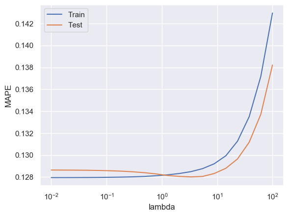

```
Best MAE= 0.2708 at lambda = 5.4556
```

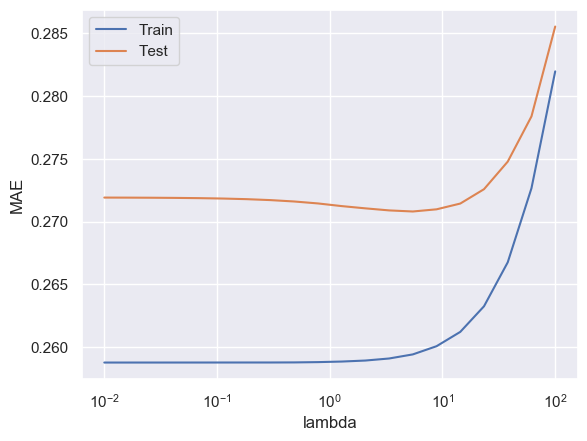

```
Best RMSE= 0.4913 at lambda = 0.0100
```

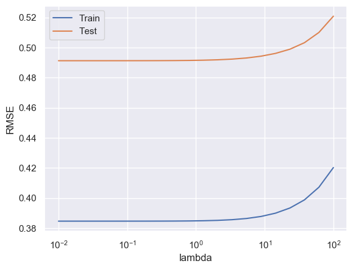

```
Best R2= 0.7800 at lambda = 0.0100
```

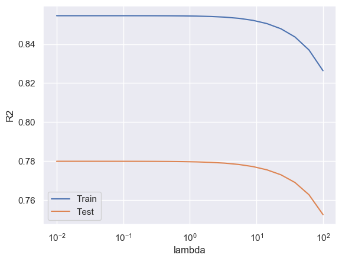

```python
#Cosider the range between 0.01 and 100
lamgrids = np.geomspace(0.01, 100, num=20)
performance_type = ["MAPE", "MAE", "RMSE", "R2"]

for i in performance_type:
    perf_train, perf_test = ridge_perf_by_alphas(X_train, y_train, lamgrids, perfname = i)

    if i == "R2":
        tmpind = np.argmax(perf_test)
    else:
        tmpind = np.argmin(perf_test)
    best_lambda = lamgrids[tmpind]
    best_mape_test = perf_test[tmpind, 0]
    print(f"Best {i}= {best_mape_test:.4f} at lambda = {best_lambda:.4f}")

    plt.plot(lamgrids, perf_train, label = "Train")
    plt.plot(lamgrids, perf_test, label = "Test")
    plt.xscale("log")
    plt.xlabel("lambda")
    plt.ylabel(i)
    plt.legend()
    plt.show()
```